# InititalAnalysis

To DO: find a good analysis to prove these clsuters, factors. Include fit of the models in this visulaization and analysis, as well as the variation of parameter values between samples,

```r
PCAres = principal(cor(data), nfactors =19, rotate = "varimax")
```

```
## In factor.stats, the correlation matrix is singular, an approximation is used
```

```r
summary(PCAres)
```

```
##
## Factor analysis with Call: principal(r = cor(data), nfactors = 19, rotate = "varimax")
##
## Test of the hypothesis that 19 factors are sufficient.
## The degrees of freedom for the model is 8109  and the objective function was  125.3
##
## The root mean square of the residuals (RMSA) is  0.03
```

```r
print(PCAres)
```

```
## Principal Components Analysis
## Call: principal(r = cor(data), nfactors = 19, rotate = "varimax")
## Standardized loadings (pattern matrix) based upon correlation matrix
##                                        RC1   RC3   RC2   RC6   RC5   RC7
## alpha_Aspiration                     -0.06 -0.02 -0.38  0.40  0.08 -0.06
## beta_Aspiration                      -0.05 -0.02 -0.39  0.39  0.06 -0.05
## delta_Aspiration                      0.20 -0.06  0.02  0.04 -0.08 -0.01
## epsilon_Aspiration                   -0.01  0.00 -0.01  0.06  0.00  0.82
## gamma_Aspiration                      0.74  0.05  0.23 -0.08 -0.08 -0.03
## epsilon_Below.mean.Semivariance       0.00  1.00  0.00  0.00  0.00  0.00
## kappa_Below.mean.Semivariance        -0.16 -0.01 -0.15  0.16  0.79 -0.04
## epsilon_Certainty.Equivalence         0.69  0.01 -0.02 -0.04 -0.07  0.09
## epsilon_CoefVar                       0.01  1.00  0.01  0.00  0.00  0.00
## kappa_CoefVar                        -0.26 -0.04  0.08 -0.15 -0.10  0.12
## delta_CPT.LBW                         0.23  0.00  0.26 -0.21 -0.16  0.00
## epsilon_CPT.LBW                      -0.18  0.00 -0.20  0.52 -0.04 -0.05
## gamma_CPT.LBW                         0.81  0.04  0.13 -0.17  0.05 -0.03
## tau_CPT.LBW                           0.02  0.04  0.80 -0.21 -0.02 -0.01
## beta_CPT.Prelec                      -0.05  0.00 -0.16 -0.07  0.16  0.11
## epsilon_CPT.Prelec                   -0.34 -0.01 -0.16  0.30 -0.06 -0.06
## gamma_CPT.Prelec                      0.66  0.06  0.19 -0.13  0.02  0.00
## tau_CPT.Prelec                        0.04  0.04  0.74  0.08  0.05  0.01
## epsilon_CPT.TK                       -0.06  0.00 -0.06  0.07  0.11  0.04
## gamma_CPT.TK                          0.86  0.02 -0.01 -0.13  0.06 -0.03
## tau_CPT.TK                            0.12  0.03  0.73 -0.10 -0.23 -0.03
## epsilon_DFT                           0.06  0.97  0.03  0.01  0.00 -0.01
## gamma_DFT                             0.62  0.03 -0.10  0.21  0.04 -0.08
## epsilon_Disappointment.Bell           0.02  0.50  0.03 -0.03  0.01 -0.01
## nu_Disappointment.Bell                0.00  0.00 -0.08  0.10 -0.76 -0.02
## alpha_Disappointment.DC1              0.16 -0.01  0.05  0.16  0.06 -0.04
## beta_Disappointment.DC1               0.02 -0.02 -0.13 -0.07 -0.02 -0.02
## epsilon_Disappointment.DC1            0.02  0.03  0.05  0.00  0.00  0.00
## kappa_Disappointment.DC1              0.04 -0.03 -0.17  0.09  0.00  0.00
## lambda_Disappointment.DC1             0.20 -0.02 -0.02  0.02  0.18 -0.03
## alpha_Disappointment.DC2             -0.22  0.00  0.05  0.07 -0.03 -0.04
## beta_Disappointment.DC2              -0.22  0.00 -0.02 -0.01 -0.06 -0.01
## epsilon_Disappointment.DC2            0.03  0.00  0.10  0.01  0.02 -0.01
## gamma_Disappointment.DC2              0.73  0.04 -0.01  0.01  0.00 -0.02
## kappa_Disappointment.DC2             -0.03 -0.02 -0.06 -0.03  0.05 -0.02
## lambda_Disappointment.DC2            -0.01 -0.02  0.01 -0.05  0.05 -0.02
```

[output cut: 560 more lines]

```
## Proportion Explained   0.21  0.13  0.13 0.08 0.06 0.04 0.04 0.04 0.04 0.03
## Cumulative Proportion  0.21  0.34  0.46 0.54 0.59 0.64 0.68 0.71 0.75 0.78
##                       RC16  RC9 RC10 RC17 RC11 RC15 RC19 RC12 RC18
## SS loadings           2.78 2.72 2.68 2.41 2.38 2.20 2.11 1.99 1.88
## Proportion Var        0.02 0.02 0.02 0.02 0.02 0.01 0.01 0.01 0.01
## Cumulative Var        0.52 0.54 0.56 0.57 0.59 0.60 0.62 0.63 0.65
## Proportion Explained  0.03 0.03 0.03 0.03 0.03 0.02 0.02 0.02 0.02
## Cumulative Proportion 0.81 0.84 0.86 0.89 0.91 0.94 0.96 0.98 1.00
##
## Mean item complexity =  2.6
## Test of the hypothesis that 19 components are sufficient.
##
## The root mean square of the residuals (RMSR) is  0.03
##
## Fit based upon off diagonal values = 0.98
```

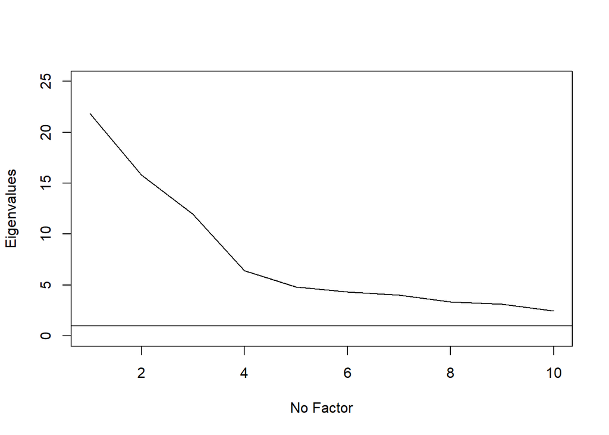

```r
plot(seq(1:10),PCAres$values[1:10], type = "l", ylab ="Eigenvalues", xlab="No Factor", ylim =c(0,25))
abline(h = 1)
```

```r
sort(abs(PCAres$loadings[,1]), decreasing = T)[1:20]
```

```
##                     gamma_EUT                gamma_PT.Edit1
##                     0.8908411                     0.8760883
##          gamma_Odds.based.SWU         gamma_Noisy.Retrieval
##                     0.8642312                     0.8635078
##         gamma_Dual.System.LOB                  gamma_CPT.TK
##                     0.8588175                     0.8563756
##                     gamma_TAX                     gamma_SEU
##                     0.8475933                     0.8384452
##                gamma_PT.Edit2      gamma_Disappointment.LS2
##                     0.8235519                     0.8218283
##                     gamma_RAM                 gamma_CPT.LBW
##                     0.8212987                     0.8121078
##                 gamma_Venture               gamma_Regret.LS
##                     0.7814479                     0.7631674
##                gamma_Salience              gamma_Aspiration
##                     0.7463302                     0.7439811
##      gamma_Disappointment.DC2 epsilon_Certainty.Equivalence
##                     0.7324260                     0.6853697
##          gamma_Distracted.DFT              gamma_CPT.Prelec
##                     0.6636148                     0.6633218
```

```r
#write.csv(PCAres$loadings[,1:5], file = "PCLoadingsidenticalremoved.csv")

sort(abs(PCAres$loadings[,2]), decreasing = T)[1:20]
```

```
##                  epsilon_CoefVar              epsilon_Regret.Bell
##                        0.9965156                        0.9962022
##            epsilon_Mean.Variance        epsilon_Mean.Below.target
##                        0.9961246                        0.9960757
##  epsilon_Below.mean.Semivariance        epsilon_Mean.Alpha.target
##                        0.9959650                        0.9957318
## epsilon_Mean.Target.Semivariance        epsilon_Variance.Skewness
##                        0.9956900                        0.9955432
##       epsilon_Disappointment.LS1                      epsilon_DFT
##                        0.9948514                        0.9706411
##                       epsilon_EV                      epsilon_SEM
##                        0.9468581                        0.8532146
##      epsilon_Disappointment.Bell              epsilon_Mean.StdDev
##                        0.4987325                        0.4795195
##             kappa_Heuristic.RELM                   epsilon_Dual.1
##                        0.4476663                        0.1316208
##             omega_Heuristic.LEPE                         iota_UWS
##                        0.1264237                        0.1084592
##   omega_Heuristic.Minimax.Regret               omega_Heuristic.EP
##                        0.1084335                        0.1084334
```

```r
sort(abs(PCAres$loadings[,3]), decreasing = T)[1:20]
```

```
##                tau_Odds.based.SWU                           tau_TAX
##                         0.8804006                         0.8573350
##                           tau_SEU                mu_Noisy.Retrieval
##                         0.8529085                         0.8013011
##                       tau_CPT.LBW                           tau_RAM
##                         0.7970210                         0.7592280
##                    tau_CPT.Prelec                        tau_CPT.TK
##                         0.7401005                         0.7264795
##                           tau_SEM                       tau_Venture
##                         0.7156885                         0.7143056
##                mu_Dual.System.LOB                      tau_PT.Edit2
##                         0.7037719                         0.6642760
##                      tau_PT.Edit1               omega_Heuristic.MPW
##                         0.6566236                         0.6078595
##                 mu_Distracted.DFT                omega_Heuristic.ML
##                         0.5713433                         0.5330029
##    omega_Heuristic.Minimax.Regret                omega_Heuristic.EP
##                         0.4904914                         0.4904914
## omega_Heuristic.Similarity.Leland           kappa_Mean.Alpha.target
##                         0.4683593                         0.4220281
```

```r
sort(abs(PCAres$loadings[,4]), decreasing = T)[1:20]
```

```
## epsilon_Noisy.Retrieval             epsilon_TAX  epsilon_Odds.based.SWU
##               0.8701421               0.8525708               0.8461081
##   kappa_Dual.System.LOB  epsilon_Distracted.DFT             epsilon_SEU
##               0.7401291               0.7390456               0.7298428
##   epsilon_Dual.System.M         epsilon_CPT.LBW       mu_Distracted.DFT
##               0.6511694               0.5160904               0.4247330
##        alpha_Aspiration      mu_Noisy.Retrieval         beta_Aspiration
##               0.4020139               0.3913302               0.3886757
##      mu_Dual.System.LOB      tau_Odds.based.SWU               gamma_TAX
##               0.3153107               0.3038564               0.3034826
##                 tau_TAX      epsilon_CPT.Prelec    gamma_Odds.based.SWU
##               0.2995343               0.2984218               0.2791947
##   gamma_Noisy.Retrieval   gamma_Dual.System.LOB
##               0.2695214               0.2689951
```

```r
sort(abs(PCAres$loadings[,5]), decreasing = T)[1:20]
```

```
##                  kappa_Mean.Variance                    kappa_Mean.StdDev
##                            0.8881105                            0.8777301
##                 nu_Variance.Skewness        kappa_Below.mean.Semivariance
##                            0.8140592                            0.7943906
##               nu_Disappointment.Bell       kappa_Mean.Target.Semivariance
##                            0.7590833                            0.7063444
##              kappa_Mean.Below.target                            kappa_TAX
##                            0.5116091                            0.2975593
##                         tau_PT.Edit1                           tau_CPT.TK
##                            0.2912769                            0.2281112
##                         beta_Venture                    kappa_Regret.Bell
##                            0.2275556                            0.2109656
##                         tau_PT.Edit2                               mu_UWS
##                            0.1831350                            0.1829247
##            lambda_Disappointment.DC1 upsilon_Subjective.Expected.Pleasure
##                            0.1772728                            0.1741277
##                  omega_Heuristic.BTA                        delta_CPT.LBW
##                            0.1606029                            0.1587491
##             kappa_Disappointment.LS1                      beta_CPT.Prelec
##                            0.1572193                            0.1564656
```

visualization of the component structure. The color indicate on which component the parameter had the highest loading. The size of the node is a linear function of the loading. the factors are sorted by Eigenvalue.

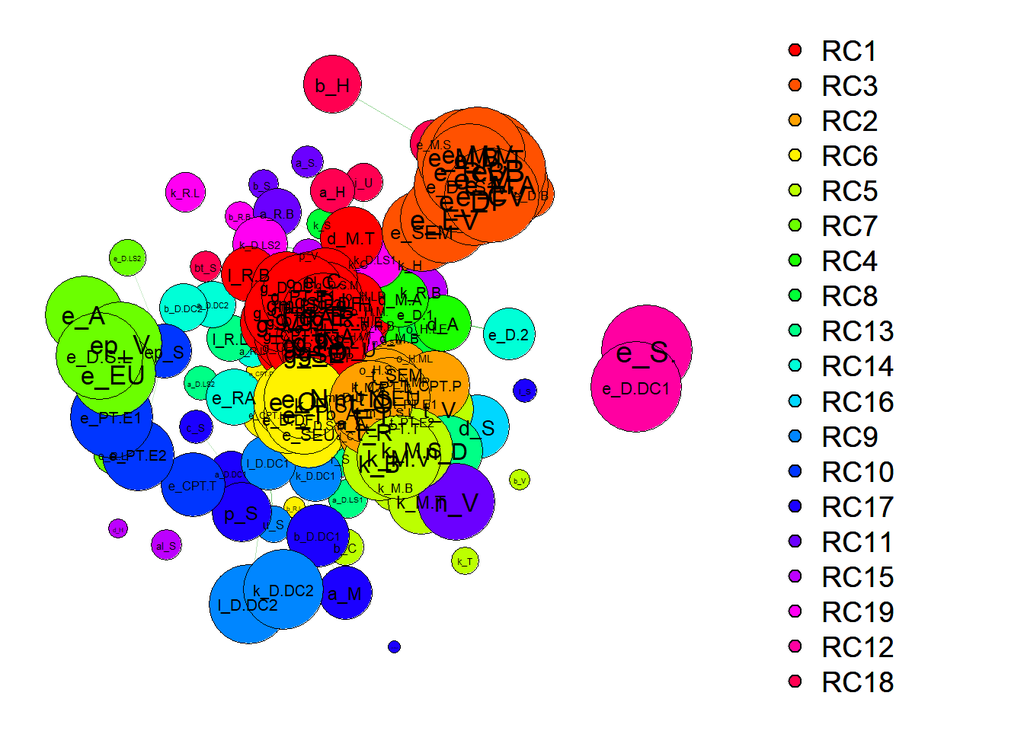

```r
maxLoadings = maxLoadingsabs = rep(NA, length(paramNames))
for (i in 1:length(paramNames)){
maxLoadings[i] = which(PCAres$loadings[i,1:19] == max(PCAres$loadings[i,1:19]))
maxLoadingsabs[i] = max(abs(PCAres$loadings[i,1:19]))
}

FactorL = list(which(maxLoadings ==1))

for (i in 2:19){
FactorL =  append(FactorL, list(which(maxLoadings ==i)))}

names(FactorL) = colnames(PCAres$loadings)[1:19]


maxLoadingsabs =5*maxLoadingsabs

maxLoadingsabs = setNames(maxLoadingsabs, seq(1:length(paramNames)))



colnames(data)  = seq(1:length(colnames(data)))
for (c in 1:dim(data)[2]){
colnames(data)[c] = paste0(paramFAC[c], "_" , modelFAC[c])
}

qgraph(cor(data), minimum = .3, layout = "spring",  groups = FactorL, graph = "cor", legend = T, vsize = 2*maxLoadingsabs)
```

In the following visualization only the six extraccted components are illustarted. Again color illustrates the factor on which the parameter has the highest loading and the size is a linear function of the loading on this parameter

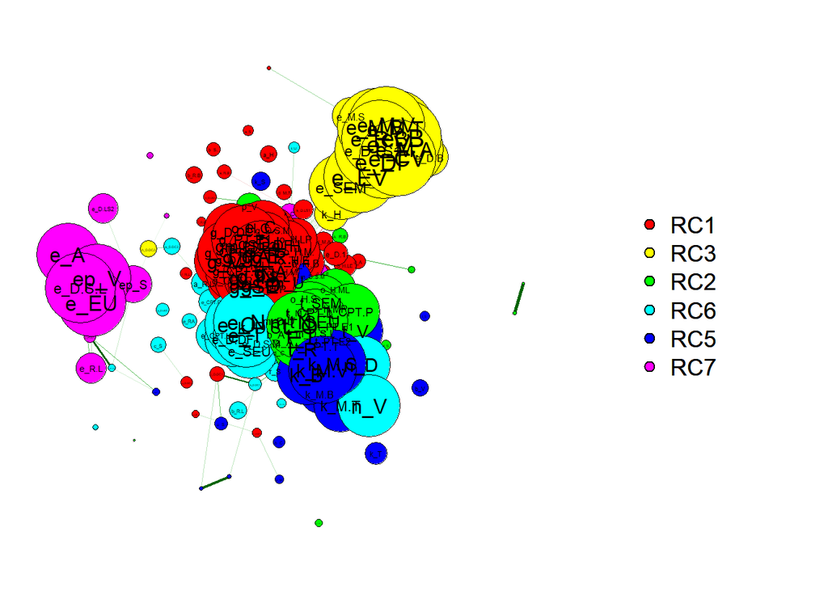

```r
maxLoadings = maxLoadingsabs = rep(NA, length(paramNames))
for (i in 1:length(paramNames)){
maxLoadings[i] = which(PCAres$loadings[i,1:6] == max(PCAres$loadings[i,1:6]))
maxLoadingsabs[i] = max(abs(PCAres$loadings[i,1:6]))
}

FactorL = list(which(maxLoadings ==1))

for (i in 2:6){
FactorL =  append(FactorL, list(which(maxLoadings ==i)))}

names(FactorL) = colnames(PCAres$loadings)[1:6]


maxLoadingsabs =5*maxLoadingsabs

maxLoadingsabs = setNames(maxLoadingsabs, seq(1:length(paramNames)))



colnames(data)  = seq(1:length(colnames(data)))
for (c in 1:dim(data)[2]){
colnames(data)[c] = paste0(paramFAC[c], "_" , modelFAC[c])
}

qgraph(cor(data), minimum = .3, layout = "spring",  groups = FactorL, graph = "cor", legend = T, vsize = 2*maxLoadingsabs)
```

Calculation of a profile for each model based on the average , absolute loadings of the model’s parameters on the factor.

```r
Profiles =array(NA, dim = c(length(models), 8))
i = 1
for(p in 1:6){
for(m in 1:length(models)){
Profiles[m, p]=(sum(abs(PCAres$loadings[which(modelNames == models[m]),p]))/CorrModelParams$nPars[m])
i = i+CorrModelParams$nPars[m]
Profiles[m,7] = sumBIC[which(names(sumBIC) == models[m])]
Profiles[m,8] = CorrModelParams$meanExpCV[CorrModelParams$Name == models[m]]
}
  }

head(Profiles)
```

```
##            [,1]        [,2]       [,3]       [,4]       [,5]       [,6]
## [1,] 0.21326543 0.028124658 0.20641997 0.19325235 0.05931240 0.19601114
## [2,] 0.07928661 0.500736459 0.07297572 0.08457223 0.39894093 0.01992295
## [3,] 0.68536967 0.006889553 0.01898081 0.03918068 0.06813923 0.09374613
## [4,] 0.13326035 0.516424646 0.04113381 0.07786535 0.05067516 0.06018971
## [5,] 0.31131802 0.022832487 0.34742485 0.27806002 0.06671015 0.02299789
## [6,] 0.27275035 0.029886173 0.31420572 0.14328217 0.07215178 0.04347432
##           [,7]      [,8]
## [1,]  73430.56 1.6529168
## [2,]  76761.47 2.7884327
## [3,]  90519.94 2.7884327
## [4,] 110502.27 2.2710713
## [5,]  73381.49 0.5934500
## [6,]  71309.55 0.7738333
```

```r
colnames(Profiles) = c(colnames(PCAres$loadings)[1:6],
                       #"PCA5","PCA6",
                       "fit", "ExpCV")

Profiles = as.data.frame(Profiles)
```

Predict model fit (summed BIC) with the models Profiles

```r
modelFit = lm(fit ~ RC1*RC6 +RC2*RC6 +. - ExpCV, Profiles)
summary(modelFit)
```

```
##
## Call:
## lm(formula = fit ~ RC1 * RC6 + RC2 * RC6 + . - ExpCV, data = Profiles)
##
## Residuals:
##    Min     1Q Median     3Q    Max
## -15146  -4807      1   4894  25721
##
## Coefficients:
##             Estimate Std. Error t value Pr(>|t|)
## (Intercept)    82645       5378  15.366   <2e-16 ***
## RC1            -7016      12875  -0.545   0.5885
## RC6           -47508      48957  -0.970   0.3372
## RC2            29233      12910   2.264   0.0285 *
## RC3             9041       7504   1.205   0.2347
## RC5            -1999      13236  -0.151   0.8806
## RC7            -7762      17221  -0.451   0.6544
## RC1:RC6       203263     124779   1.629   0.1105
## RC6:RC2      -200380     117029  -1.712   0.0939 .
## ---
## Signif. codes:  0 '***' 0.001 '**' 0.01 '*' 0.05 '.' 0.1 ' ' 1
##
## Residual standard error: 9049 on 44 degrees of freedom
## Multiple R-squared:  0.3773, Adjusted R-squared:  0.2641
## F-statistic: 3.333 on 8 and 44 DF,  p-value: 0.004589
```

```r
library(BayesFactor)
modelBF= generalTestBF(fit ~ RC1*RC6 +RC2*RC6 +. - ExpCV, Profiles)
sort(modelBF, decreasing  = T)[1:10]
```

```
## Bayes factor analysis
## --------------
## [1] RC6                                  : 122.7105 ±0%
## [2] RC6 + RC2                            : 96.51862 ±0%
## [3] RC6 + RC2 + RC6:RC2                  : 55.84169 ±0.01%
## [4] RC1 + RC6                            : 52.69284 ±0%
## [5] RC6 + RC2 + RC3                      : 50.03042 ±0.01%
## [6] RC6 + RC7                            : 49.40988 ±0%
## [7] RC6 + RC2 + RC7                      : 41.11914 ±0.01%
## [8] RC6 + RC3                            : 39.1548  ±0%
## [9] RC1 + RC6 + RC2                      : 37.4821  ±0%
## [10] RC1 + RC6 + RC2 + RC1:RC6 + RC6:RC2 : 35.41328 ±0.01%
##
## Against denominator:
##   Intercept only
## ---
## Bayes factor type: BFlinearModel, JZS
```

Predict variation between experiments average coefficient of variation of the model’s parameters between the experiments.

```r
modelExpCV = lm(ExpCV ~. - fit, Profiles)
summary(modelExpCV)
```

```
##
## Call:
## lm(formula = ExpCV ~ . - fit, data = Profiles)
##
## Residuals:
##     Min      1Q  Median      3Q     Max
## -3.5229 -0.2312  0.0192  0.3194  2.5131
##
## Coefficients:
##             Estimate Std. Error t value Pr(>|t|)
## (Intercept)   0.7326     0.3937   1.861   0.0691 .
## RC1           1.1658     0.7491   1.556   0.1265
## RC3           0.8447     0.6676   1.265   0.2122
## RC2           0.3397     0.8479   0.401   0.6905
## RC6          -1.6042     0.9776  -1.641   0.1076
## RC5           3.3447     1.1730   2.851   0.0065 **
## RC7           1.8733     1.5013   1.248   0.2184
## ---
## Signif. codes:  0 '***' 0.001 '**' 0.01 '*' 0.05 '.' 0.1 ' ' 1
##
## Residual standard error: 0.8063 on 46 degrees of freedom
## Multiple R-squared:  0.2781, Adjusted R-squared:  0.1839
## F-statistic: 2.953 on 6 and 46 DF,  p-value: 0.016
```

```r
modelBF= generalTestBF(ExpCV ~ RC1*RC6 +RC2*RC6 +. - fit, Profiles)
sort(modelBF, decreasing  = T)[1:10]
```

```
## Bayes factor analysis
## --------------
## [1] RC1 + RC6 + RC5              : 10.52149 ±0%
## [2] RC6 + RC5                    : 9.366825 ±0%
## [3] RC5                          : 6.961058 ±0%
## [4] RC6 + RC5 + RC7              : 6.627241 ±0%
## [5] RC1 + RC6 + RC3 + RC5        : 6.149828 ±0%
## [6] RC1 + RC6 + RC5 + RC7        : 6.031036 ±0%
## [7] RC1 + RC5                    : 5.605027 ±0.01%
## [8] RC1 + RC3 + RC5              : 4.640295 ±0%
## [9] RC5 + RC7                    : 4.629771 ±0.01%
## [10] RC1 + RC6 + RC3 + RC5 + RC7 : 4.61587  ±0%
##
## Against denominator:
##   Intercept only
## ---
## Bayes factor type: BFlinearModel, JZS
```

[figure not shown]

To DO: find a good analysis to prove these clsuters, factors. Include fit of the models in this visulaization and analysis, as well as the variation of parameter values between samples,

```r
-c(which(colnames(data) == "EXPERIMENT"),
which(colnames(data) == "ï..SUBJ.ID") )

#
# ## Mean absolute Param Correlations in Models with Epsilon
CorrModelParams[CorrModelParams$Name %in% modelNames[which(Epsilons == T)],4]

CorrModelParams[CorrModelParams$Name %in% modelNames[which(Gammas == T)],4]
CorrModelParams[!(CorrModelParams$Name %in% modelNames[which(Epsilons == T)]),4]
#
# ## Mean absolute Param Correlations in Models with Gamma
# CorrModelParams[CorrModelParams$Name %in% modelNames[which(Gammas == T)],4]
# CorrModelParams[!(CorrModelParams$Name %in% modelNames[which(Gammas == T)]),4]
```

### Check for differences between Experiments

```r
###  Diffferences between Experiments

anova(lm(CPT.TK__epsilon~EXPERIMENT, data = data))
round(with(data, tapply(CPT.TK__epsilon, EXPERIMENT, mean)),3)
## where do these extreme values come from?
round(with(data, tapply(CPT.TK__epsilon, EXPERIMENT, median)),3)

anova(lm(CPT.TK__gamma~EXPERIMENT, data = data))
with(data, tapply(CPT.TK__gamma, EXPERIMENT, mean))
with(data, tapply(CPT.TK__gamma, EXPERIMENT, median))
```

needs to be elaborated further